# Exploratory Data Analysis on Crime in Austin, Texas

Maya Joiner

2022-12-22

```r
library(tidyverse)
```

## Introduction

In this notebook, I will analyze different aspects of data on crime in Austin, Texas. To get the csv files I import in this notebook, I used BigQuery (SQL) to filter/group data/make new columns. Here are the code snippets I used to make the dataframes:

#### 1) Analyzing incident distribution by district

SELECT district, COUNT(unique_key) AS number_crimes FROM `bigquery-public-data.austin_crime.crime` GROUP BY district;

#### 2) Type of incident by district

SELECT district, latitude, longitude, primary_type FROM `bigquery-public-data.austin_crime.crime` WHERE latitude IS NOT NULL;

#### 3) How long it took for a case to be cleared by district

SELECT district, EXTRACT(HOUR from clearance_date-timestamp) AS difference_hours, timestamp, clearance_date FROM `bigquery-public-data.austin_crime.crime`

#### 4) Incident count over time by district

SELECT district, EXTRACT(YEAR from timestamp) AS crime_year, COUNT(unique_key) AS number_crimes FROM `bigquery-public-data.austin_crime.crime` GROUP BY district, crime_year ORDER BY district, crime_year;

## Part 1: Analyzing incident distribution by district

```r
df1 = read.csv("crime_counts_by_district.csv")
df1
```

```
##    district number_crimes
## 1        UK           378
## 2         I         13222
## 3         H         12294
## 4         A         12915
## 5        88            26
## 6         B         13520
## 7         D         16794
## 8         F         14311
## 9         C          9142
## 10        G          8229
## 11        E         15383
## 12       AP           460
```

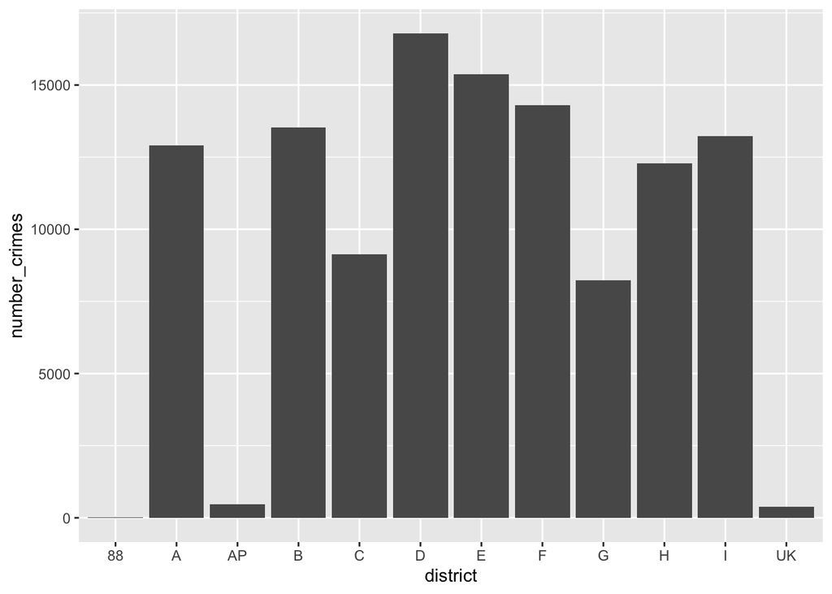

We can see that 88, AP, and UK have a very low number of crimes, followed by C and G. The other districts have about the same number of crimes, D being the highest.

## Part 2: Type of incident by district

```r
df2 = read.csv("latlong.csv")
head(df2)
```

```
##   district latitude longitude primary_type
## 1        G 30.26498  -97.7466         Rape
## 2       UK 30.26498  -97.7466         Rape
## 3        G 30.26498  -97.7466         Rape
## 4        A 30.26498  -97.7466         Rape
## 5        B 30.26498  -97.7466         Rape
## 6        G 30.26498  -97.7466         Rape
```

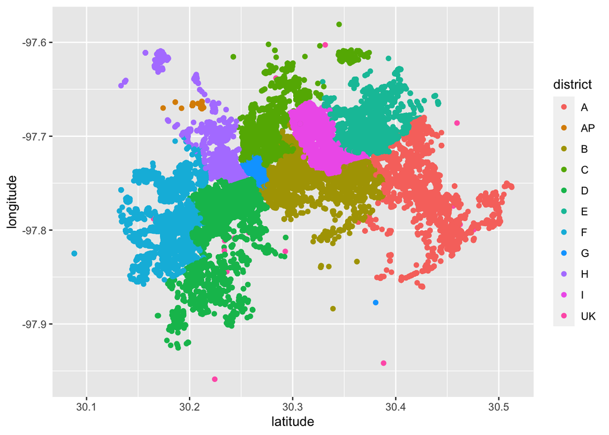

```r
ggplot(data = df2, mapping=aes(x = latitude, y = longitude, color=district) ) + geom_point()
```

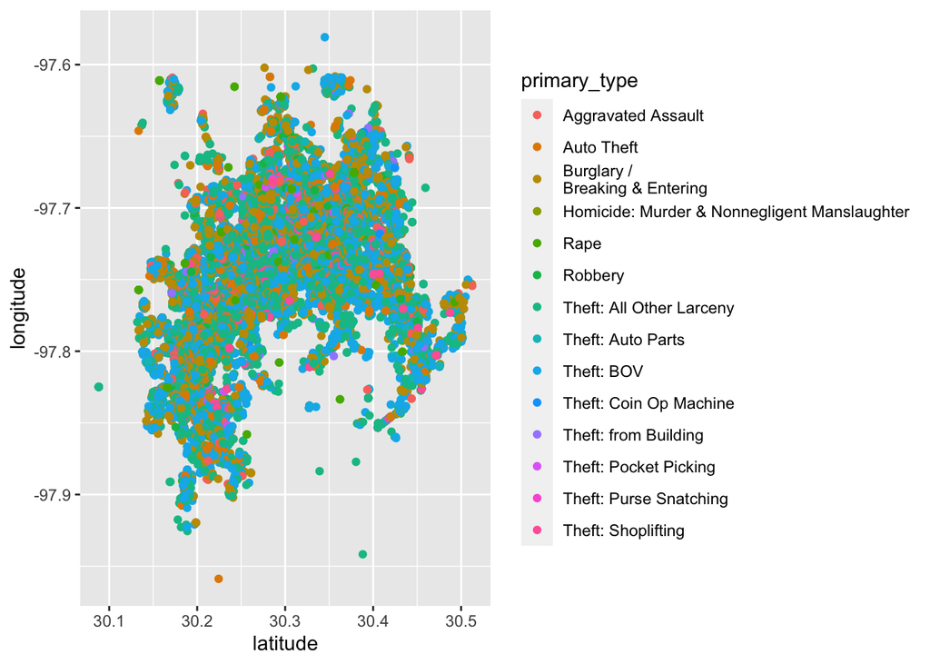

```r
ggplot(data = df2, mapping=aes(x = latitude, y = longitude, color=primary_type) ) + geom_point()
```

Although it seems like all districts have a lot of burgulary/BOV theft, we are not 100% sure because of overplotting. To resolve this, we could jitter the data or make the points smaller/have a different shape. However, since I think this graph will still be overplot even when jittered and the points are already small, I will focus on one district of the map.

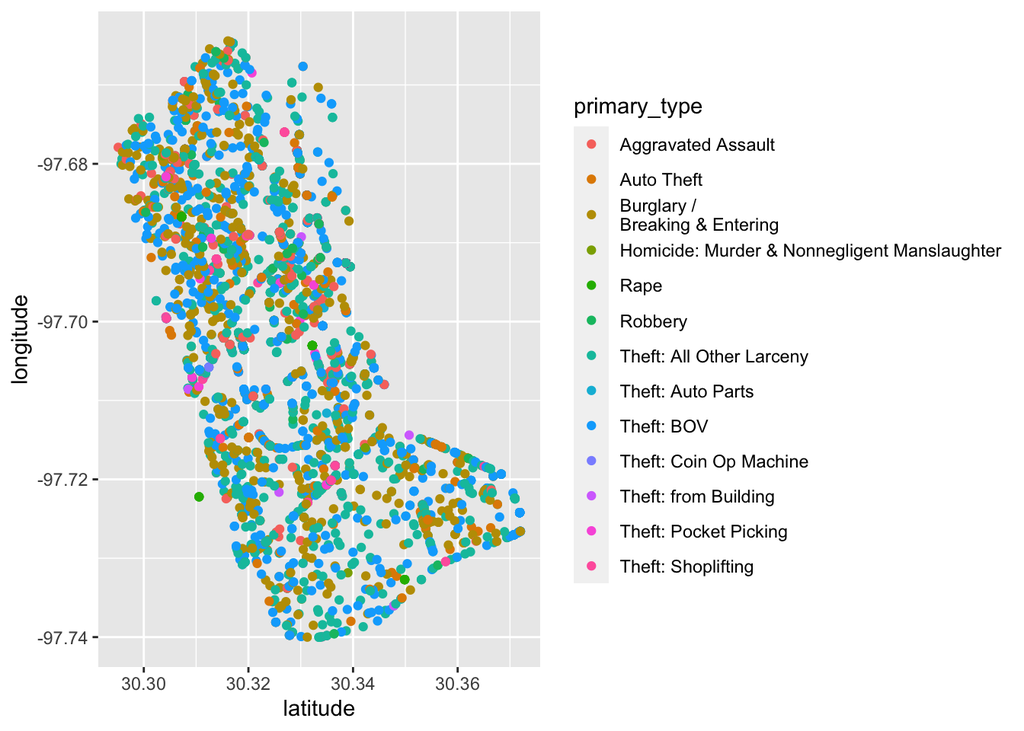

```r
ggplot(data = df2[df2$district == "I", ], mapping=aes(x = latitude, y = longitude, color=primary_type) ) + geom_point()
```

At least for district I, theft/burglary are the most common crimes.

## Part 3: How long it took for a case to be cleared by district

```r
df3 = read.csv("time_taken_to_clear.csv")
sum(is.na(df3)) / nrow(df3[complete.cases(df3),])
```

```
## [1] 0.05145646
```

Since the number of missing rows are not that significant (only 5% of all rows are missing), we will just ignore these rows. However, we still need to analyze if there is a pattern between the data that is missing.

#### Missing Analysis

```r
cases <- df3[ , c("district", "difference_hours")]
grouped <- cases %>% group_by(district) %>% summarize(count=n())
all_count <- grouped$count
```

```r
df3notna <- df3[complete.cases(df3),]
head(df3notna)
```

```
##   district difference_hours                      timestamp
## 1       UK             1320 2016-01-19 12:00:00.000000 UTC
## 2       UK             1584 2016-01-25 12:00:00.000000 UTC
## 3       UK             5640 2016-01-25 12:00:00.000000 UTC
## 4       UK             1200 2016-02-01 12:00:00.000000 UTC
## 5       UK             1128 2016-02-25 12:00:00.000000 UTC
## 6       UK             1320 2016-03-10 12:00:00.000000 UTC
##                   clearance_date
## 1 2016-03-14 12:00:00.000000 UTC
## 2 2016-03-31 12:00:00.000000 UTC
## 3 2016-09-16 12:00:00.000000 UTC
## 4 2016-03-22 12:00:00.000000 UTC
## 5 2016-04-12 12:00:00.000000 UTC
## 6 2016-05-04 12:00:00.000000 UTC
```

```r
missingdf <- df3[!complete.cases(df3), c("district", "difference_hours")]
missing <- missingdf %>% group_by(district) %>% summarize(count=n())
missing_count <- missing$count
district <- missing$district
```

```r
percent_missing <- (missing_count / all_count)*100
counts <- data.frame(district, missing_count, all_count, percent_missing)
```

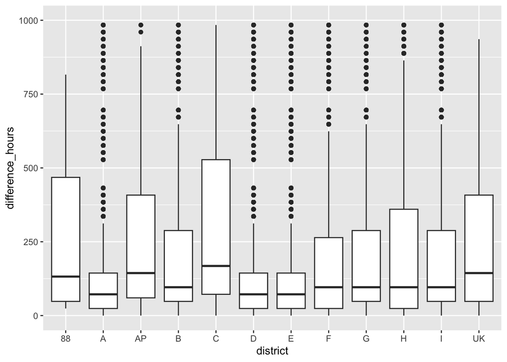

```r
ggplot(data = df3notna, mapping=aes(x = district, y = difference_hours) ) + geom_boxplot() + ylim(0, 1000)
```

## Part 4: Incident count over time by district

```r
df4 = read.csv("crime_count_over_time.csv")
df4
```

```
##    district crime_year number_crimes
## 1        88       2016            26
## 2         A       2014          4513
## 3         A       2015          4256
## 4         A       2016          4146
## 5        AP       2014           120
## 6        AP       2015           178
## 7        AP       2016           162
## 8         B       2014          4391
## 9         B       2015          4856
## 10        B       2016          4273
## 11        C       2014          3383
## 12        C       2015          2934
## 13        C       2016          2825
## 14        D       2014          5654
```

[output cut: 20 more lines]

For this part, we will remove district 88 because it only has information on one year.

```r
df4 <- df4[-1, ]
df4
```

```
##    district crime_year number_crimes
## 2         A       2014          4513
## 3         A       2015          4256
## 4         A       2016          4146
## 5        AP       2014           120
## 6        AP       2015           178
## 7        AP       2016           162
## 8         B       2014          4391
## 9         B       2015          4856
## 10        B       2016          4273
## 11        C       2014          3383
## 12        C       2015          2934
## 13        C       2016          2825
## 14        D       2014          5654
## 15        D       2015          5692
```

[output cut: 19 more lines]

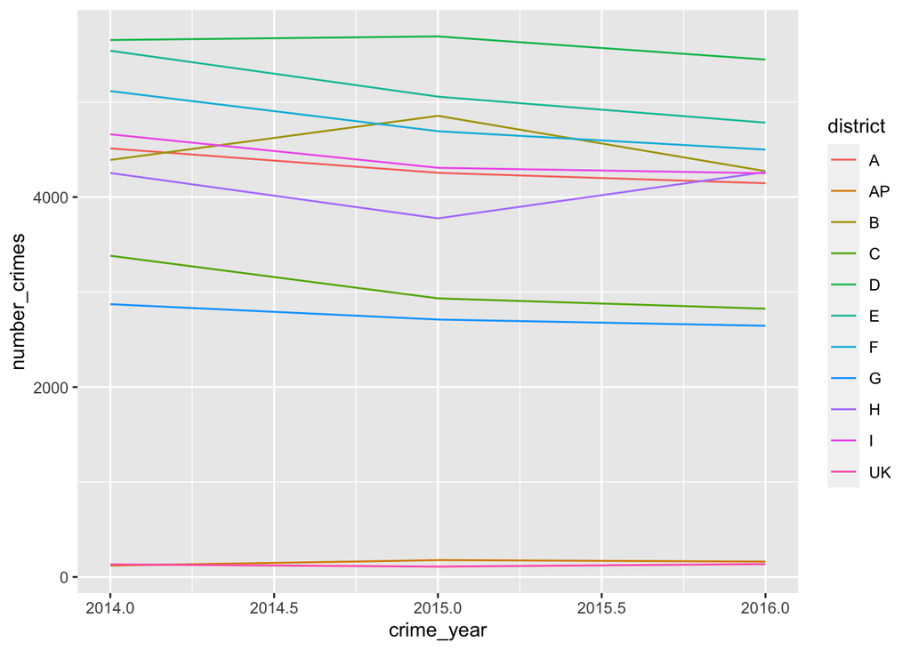

```r
ggplot(data = df4, mapping=aes(x = crime_year, y = number_crimes, color=district) ) + geom_line()
```